# examples_0416

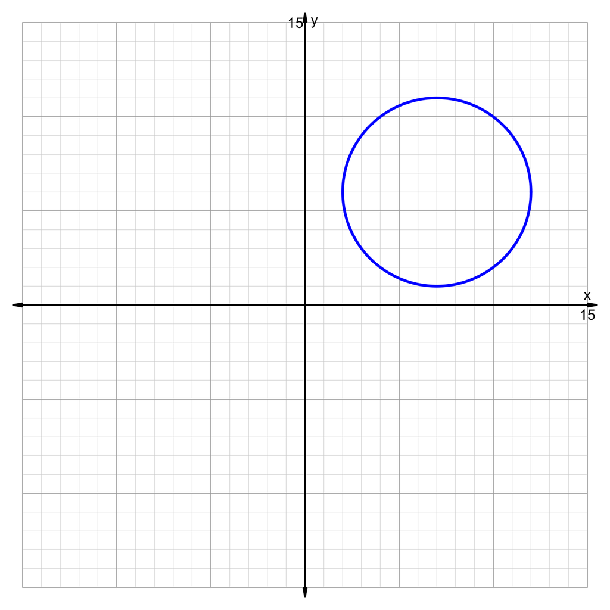

Which equation matches the circle?

$(x-7)^2+(y-6)^2=25$$(x-7)^2+(y-6)^2=5$$(x-7)^2+(y+6)^2=25$$(x-7)^2+(y+6)^2=5$$(x+7)^2+(y-6)^2=25$$(x+7)^2+(y-6)^2=5$$(x+7)^2+(y+6)^2=25$$(x+7)^2+(y+6)^2=5$

Remember the circle equation:

$$(x-h)^2+(y-k)^2~=~r^2$$

The center of the circle is at $(7, 6)$, so $h=7$ and $k=6$. The radius of the circle is the distance from the center to the edge. The radius is 5, so $r=5$.

The standard equation of the circle is shown:

$$(x-7)^2+(y-6)^2=5^2$$

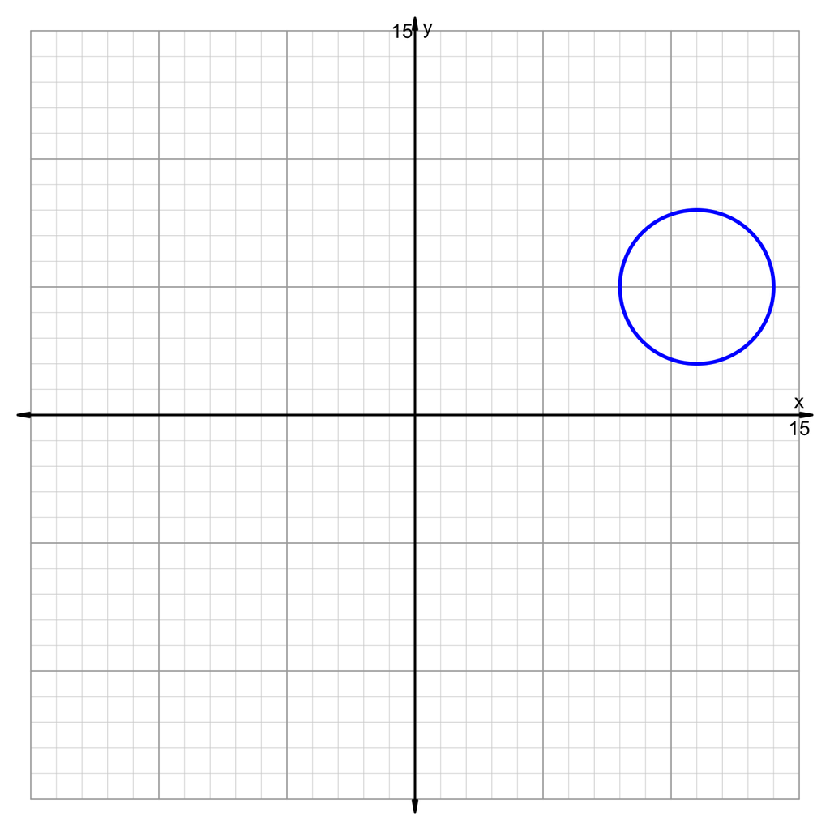

Which equation matches the circle?

$(x-11)^2+(y-5)^2=3$$(x-11)^2+(y-5)^2=9$$(x-11)^2+(y+5)^2=3$$(x-11)^2+(y+5)^2=9$$(x+11)^2+(y-5)^2=3$$(x+11)^2+(y-5)^2=9$$(x+11)^2+(y+5)^2=3$$(x+11)^2+(y+5)^2=9$

Remember the circle equation:

$$(x-h)^2+(y-k)^2~=~r^2$$

The center of the circle is at $(11, 5)$, so $h=11$ and $k=5$. The radius of the circle is the distance from the center to the edge. The radius is 3, so $r=3$.

The standard equation of the circle is shown:

$$(x-11)^2+(y-5)^2=3^2$$

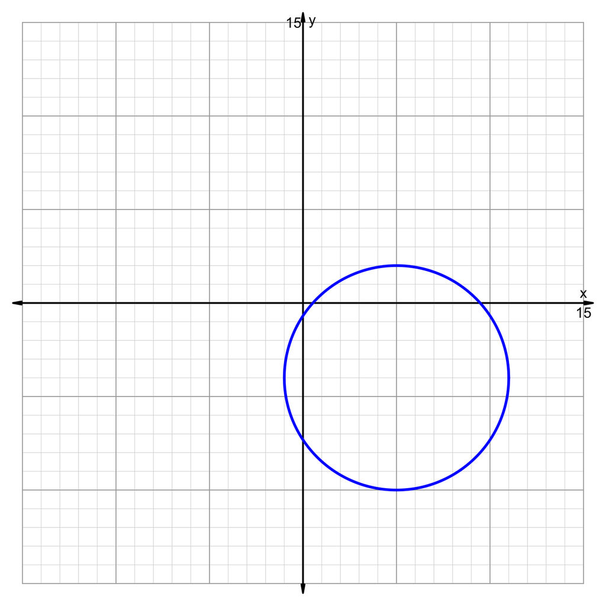

Which equation matches the circle?

$(x-5)^2+(y-4)^2=36$$(x-5)^2+(y-4)^2=6$$(x-5)^2+(y+4)^2=36$$(x-5)^2+(y+4)^2=6$$(x+5)^2+(y-4)^2=36$$(x+5)^2+(y-4)^2=6$$(x+5)^2+(y+4)^2=36$$(x+5)^2+(y+4)^2=6$

Remember the circle equation:

$$(x-h)^2+(y-k)^2~=~r^2$$

The center of the circle is at $(5, -4)$, so $h=5$ and $k=-4$. The radius of the circle is the distance from the center to the edge. The radius is 6, so $r=6$.

The standard equation of the circle is shown:

$$(x-5)^2+(y+4)^2=6^2$$

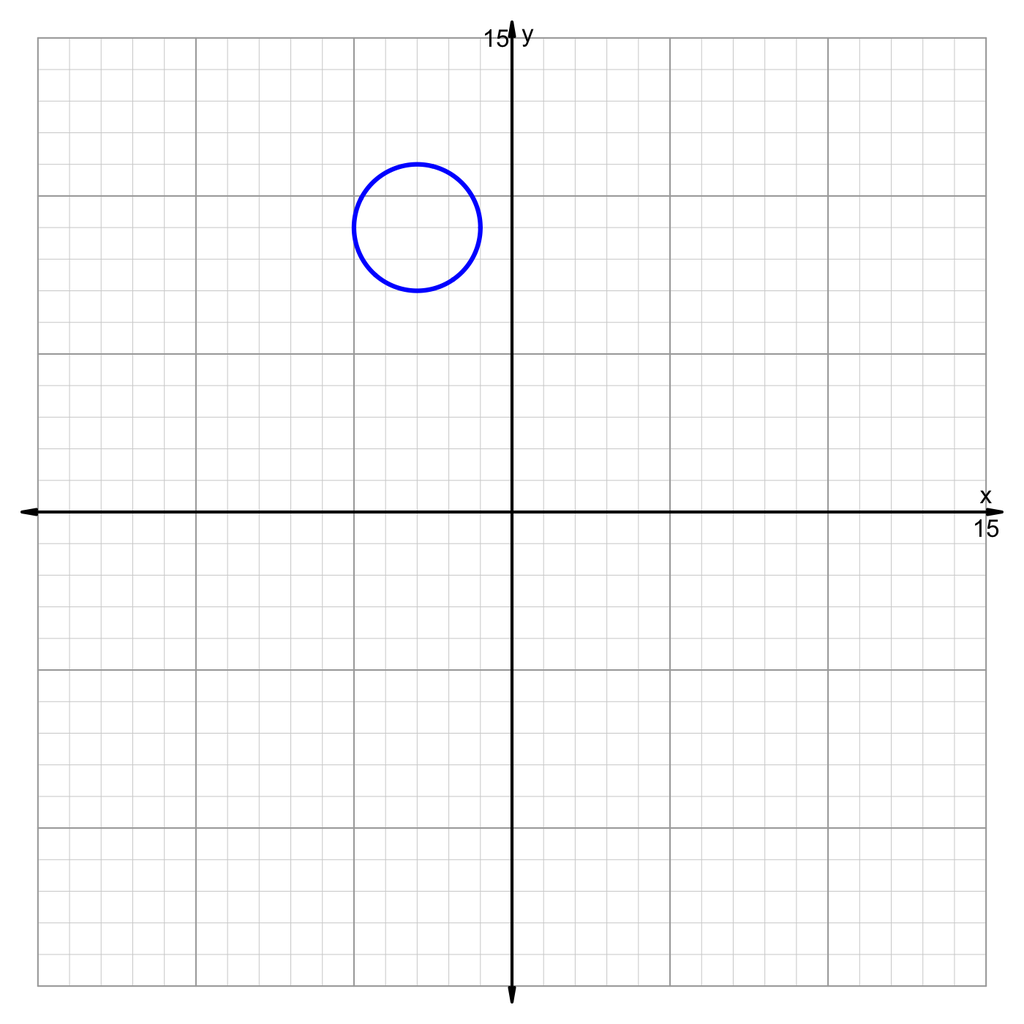

Which equation matches the circle?

$(x-3)^2+(y-9)^2=2$$(x-3)^2+(y-9)^2=4$$(x-3)^2+(y+9)^2=2$$(x-3)^2+(y+9)^2=4$$(x+3)^2+(y-9)^2=2$$(x+3)^2+(y-9)^2=4$$(x+3)^2+(y+9)^2=2$$(x+3)^2+(y+9)^2=4$

Remember the circle equation:

$$(x-h)^2+(y-k)^2~=~r^2$$

The center of the circle is at $(-3, 9)$, so $h=-3$ and $k=9$. The radius of the circle is the distance from the center to the edge. The radius is 2, so $r=2$.

The standard equation of the circle is shown:

$$(x+3)^2+(y-9)^2=2^2$$

An [ellipse](https://en.wikipedia.org/wiki/Ellipse) is a set of points such that the total distance from (1) one focus to (2) the edge to (3) the other focus is constant for any point on the edge. The two foci ($F_1$ and $F_2$) are a distance $2c$ apart, and the total distance from $F_1$ to the edge to $F_2$ is a distance $2a$.

Let's consider the example below with foci at $(-3.9,0)$ and $(3.9,0)$ and a covertex at $(0, 8)$:

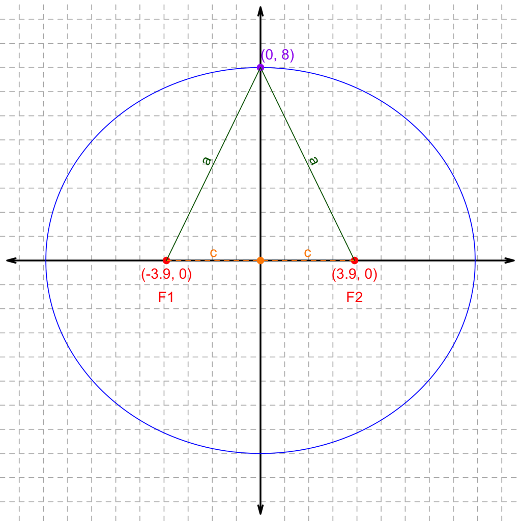

Evaluate $2a$ and $2c$.

- $a=$
- $2a=$
- $c=$
- $2c=$

Now, let's pick another point on the ellipse, with (approximate) coordinates (4.1, 7.1):

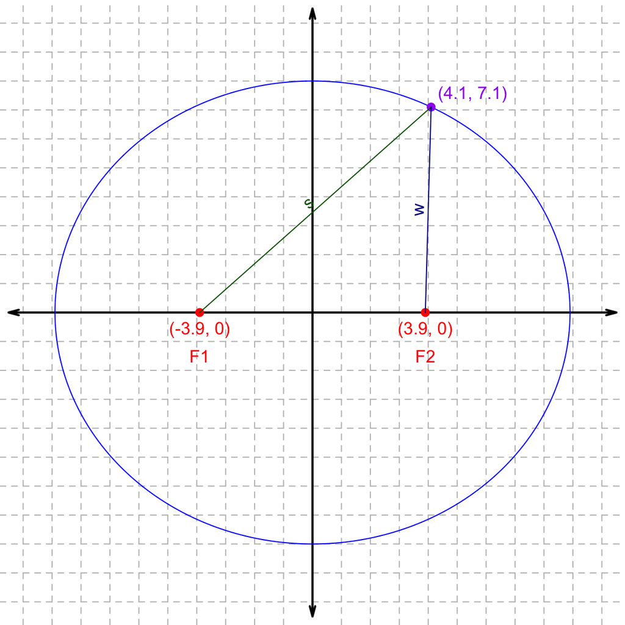

The distance $s$ is from $F_1$ to the point on the edge. The distance $w$ is from $F_2$ to the point on the edge. Evaluate $s$, $w$, and the total distance ($s+w$).

- $s=$
- $w=$
- $s+w=$

Remember, the total distance when connecting

1. The first focus $F_1$
2. Any point on the edge
3. The second focus $F_2$

equals $2a$. Based on this information, find the location of the right vertex at ($x$, 0) in the diagram below.

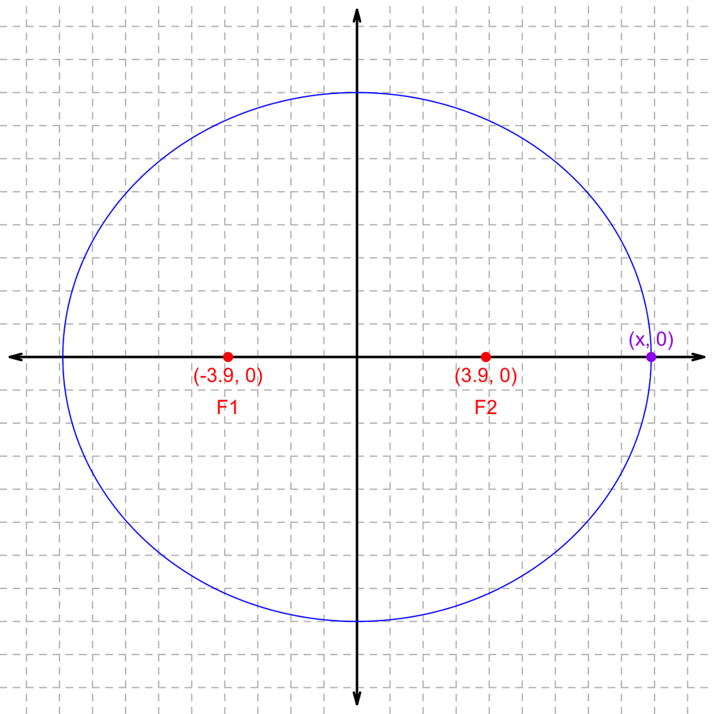

- $x=$

To find $a$, use the Pythagorean Theorem. The length $a$ is a hypotenuse of a right triangle with legs along the axes.

$$(3.9)^2 + (8)^2 =a^2$$

$$a ~=~ \sqrt{3.9^2+8^2} ~=~ 8.9$$
Use multiplication by 2 to find the total distance from $F_1$ to (0,8) to $F_2$
$$2a =
17.8$$

It is easy to find $c$ from the graph. It is the distance from the center to either focus. In this graph, the center and the focus are on the same horizontal axis, so distance is just a difference, and the subtrahend is 0.

$$c=3.9$$
$$2c = 7.8$$

Use pythagorean theorem to find $s$.

$$s =
\sqrt{(4.1-(-3.9))^2+7.1^2}$$

$$s=10.696261$$
$$s\approx10.7$$

Use pythagorean theorem to find $w$.

$$w =
\sqrt{(4.1-(3.9))^2+7.1^2}$$

$$w=7.1028163$$
$$w\approx7.1$$

Add $s$ and $w$ to get the total distance.

$$s+w=17.8$$

Notice that $s+w=2a$, because the total distance is always $2a$ for any point on the edge.

To find $x$, use the fact that the total distance is $2a$.

$$(x-(-3.9))+(x-3.9)=17.8$$
$$x+3.9+x-3.9=17.8$$
$$2x=17.8$$
$$x=8.9$$

An [ellipse](https://en.wikipedia.org/wiki/Ellipse) is a set of points such that the total distance from (1) one focus to (2) the edge to (3) the other focus is constant for any point on the edge. The two foci ($F_1$ and $F_2$) are a distance $2c$ apart, and the total distance from $F_1$ to the edge to $F_2$ is a distance $2a$.

Let's consider the example below with foci at $(-6.4,0)$ and $(6.4,0)$ and a covertex at $(0, 4.8)$:

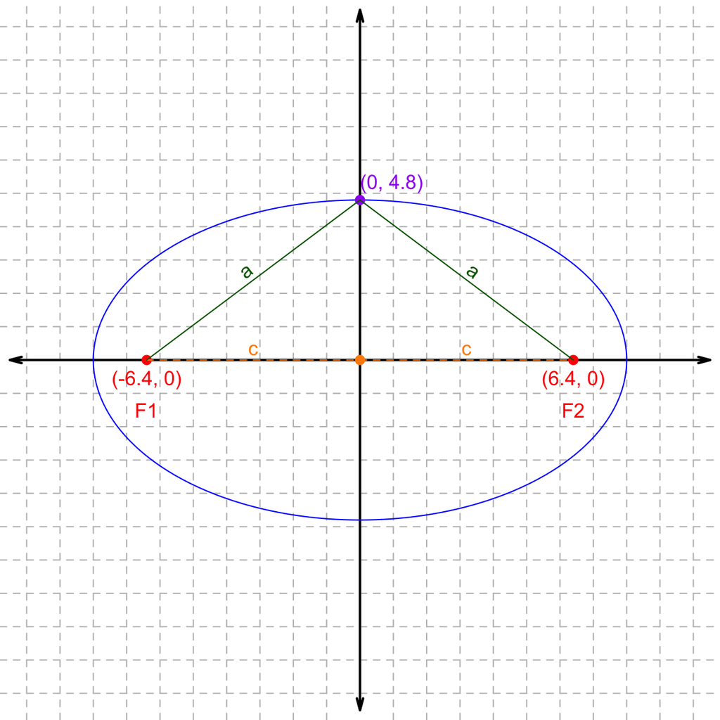

Evaluate $2a$ and $2c$.

- $a=$
- $2a=$
- $c=$
- $2c=$

Now, let's pick another point on the ellipse, with (approximate) coordinates (6.5, 2.8):

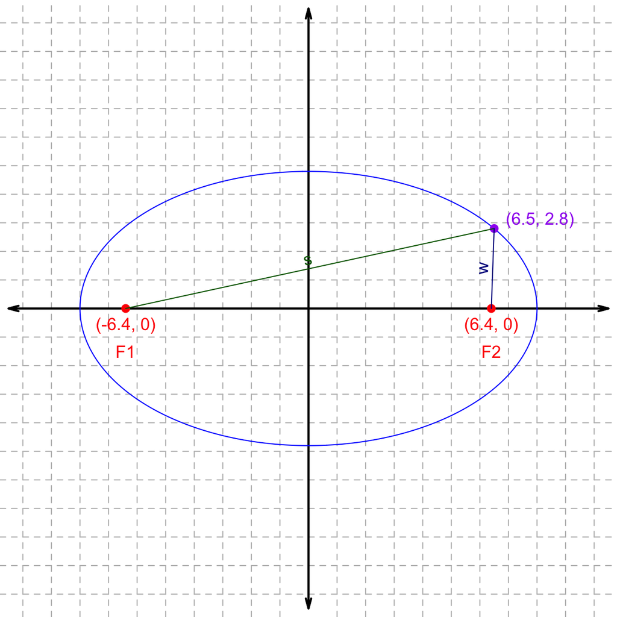

The distance $s$ is from $F_1$ to the point on the edge. The distance $w$ is from $F_2$ to the point on the edge. Evaluate $s$, $w$, and the total distance ($s+w$).

- $s=$
- $w=$
- $s+w=$

Remember, the total distance when connecting

1. The first focus $F_1$
2. Any point on the edge
3. The second focus $F_2$

equals $2a$. Based on this information, find the location of the right vertex at ($x$, 0) in the diagram below.

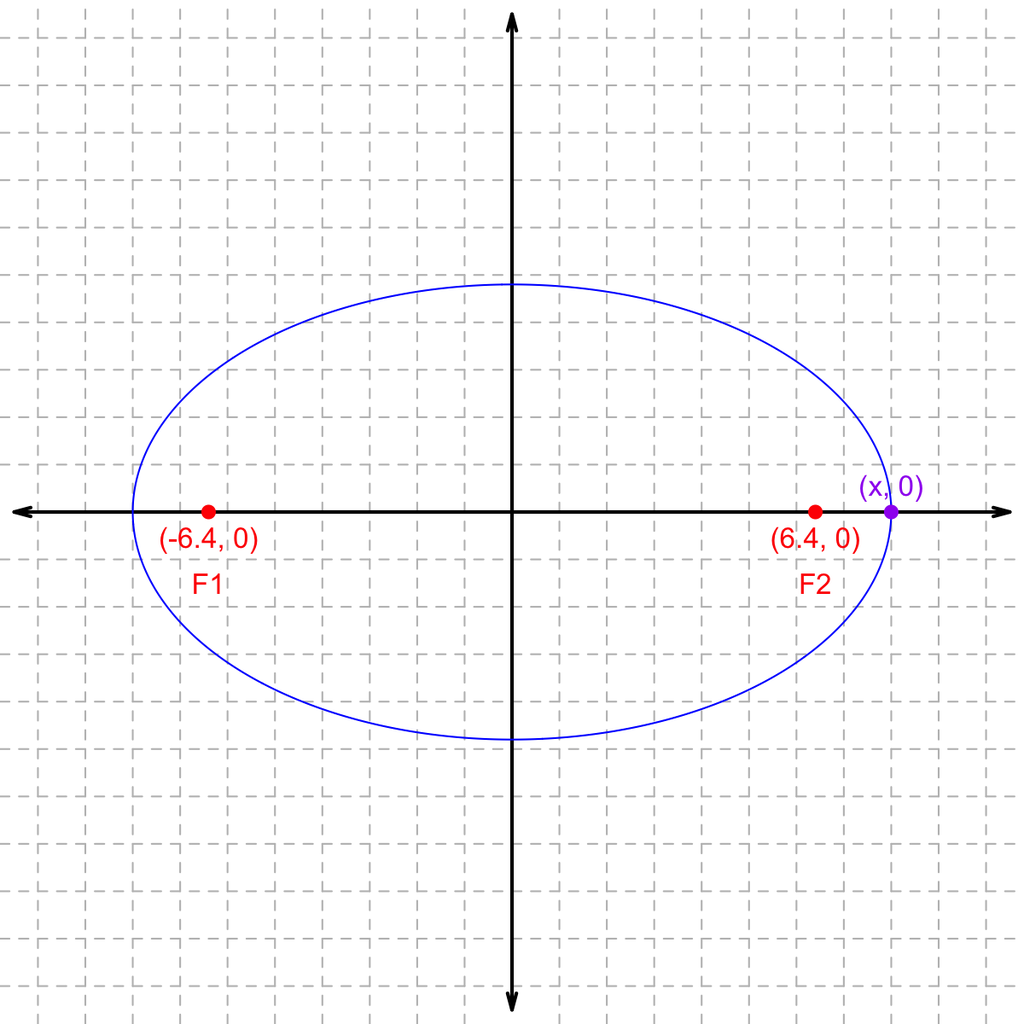

- $x=$

To find $a$, use the Pythagorean Theorem. The length $a$ is a hypotenuse of a right triangle with legs along the axes.

$$(6.4)^2 + (4.8)^2 =a^2$$

$$a ~=~ \sqrt{6.4^2+4.8^2} ~=~ 8$$
Use multiplication by 2 to find the total distance from $F_1$ to (0,4.8) to $F_2$
$$2a =
16$$

It is easy to find $c$ from the graph. It is the distance from the center to either focus. In this graph, the center and the focus are on the same horizontal axis, so distance is just a difference, and the subtrahend is 0.

$$c=6.4$$
$$2c = 12.8$$

Use pythagorean theorem to find $s$.

$$s =
\sqrt{(6.5-(-6.4))^2+2.8^2}$$

$$s=13.2003788$$
$$s\approx13.2$$

Use pythagorean theorem to find $w$.

$$w =
\sqrt{(6.5-(6.4))^2+2.8^2}$$

$$w=2.8017851$$
$$w\approx2.8$$

Add $s$ and $w$ to get the total distance.

$$s+w=16$$

Notice that $s+w=2a$, because the total distance is always $2a$ for any point on the edge.

To find $x$, use the fact that the total distance is $2a$.

$$(x-(-6.4))+(x-6.4)=16$$
$$x+6.4+x-6.4=16$$
$$2x=16$$
$$x=8$$

An [ellipse](https://en.wikipedia.org/wiki/Ellipse) is a set of points such that the total distance from (1) one focus to (2) the edge to (3) the other focus is constant for any point on the edge. The two foci ($F_1$ and $F_2$) are a distance $2c$ apart, and the total distance from $F_1$ to the edge to $F_2$ is a distance $2a$.

Let's consider the example below with foci at $(-6.5,0)$ and $(6.5,0)$ and a covertex at $(0, 7.2)$:

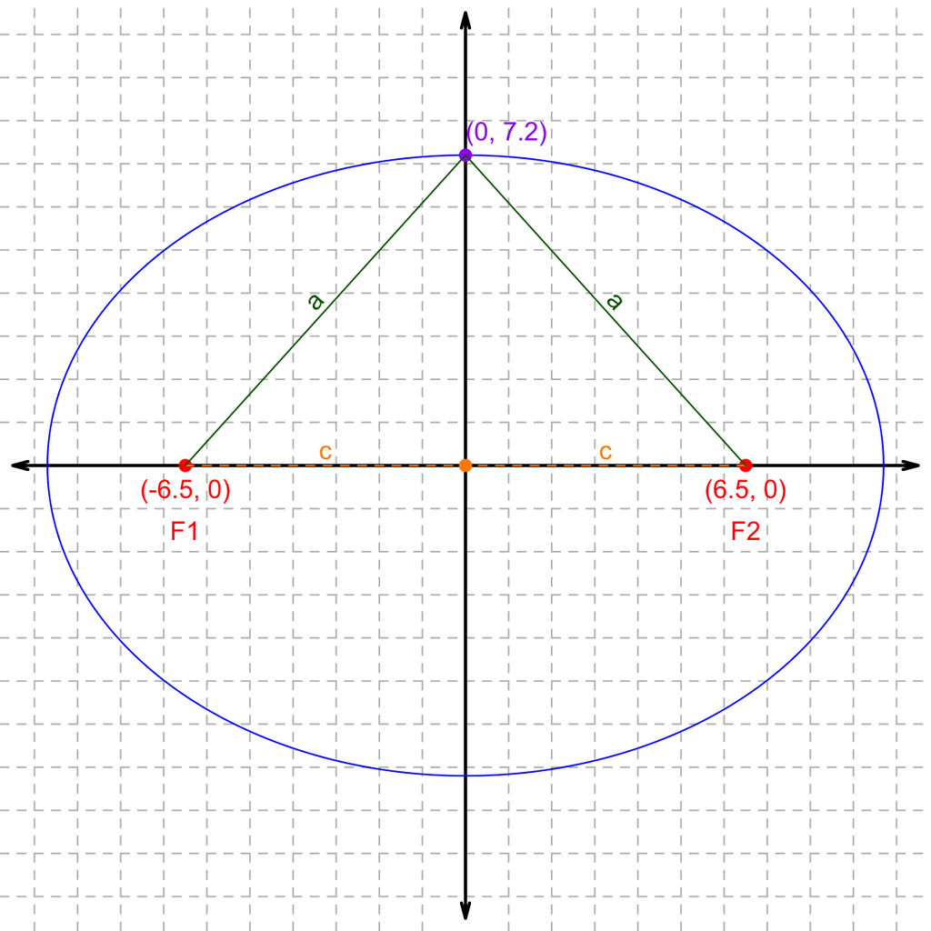

Evaluate $2a$ and $2c$.

- $a=$
- $2a=$
- $c=$
- $2c=$

Now, let's pick another point on the ellipse, with (approximate) coordinates (5.22, 6.07):

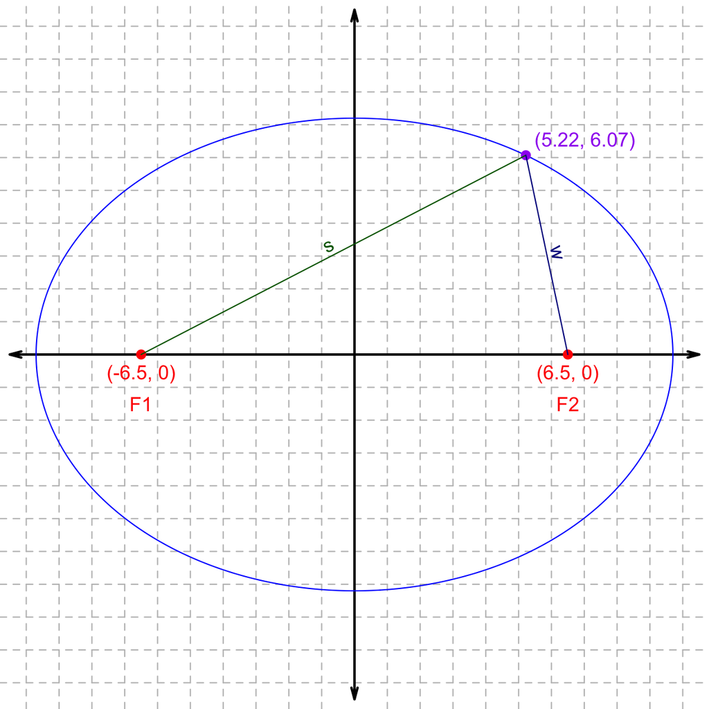

The distance $s$ is from $F_1$ to the point on the edge. The distance $w$ is from $F_2$ to the point on the edge. Evaluate $s$, $w$, and the total distance ($s+w$).

- $s=$
- $w=$
- $s+w=$

Remember, the total distance when connecting

1. The first focus $F_1$
2. Any point on the edge
3. The second focus $F_2$

equals $2a$. Based on this information, find the location of the right vertex at ($x$, 0) in the diagram below.

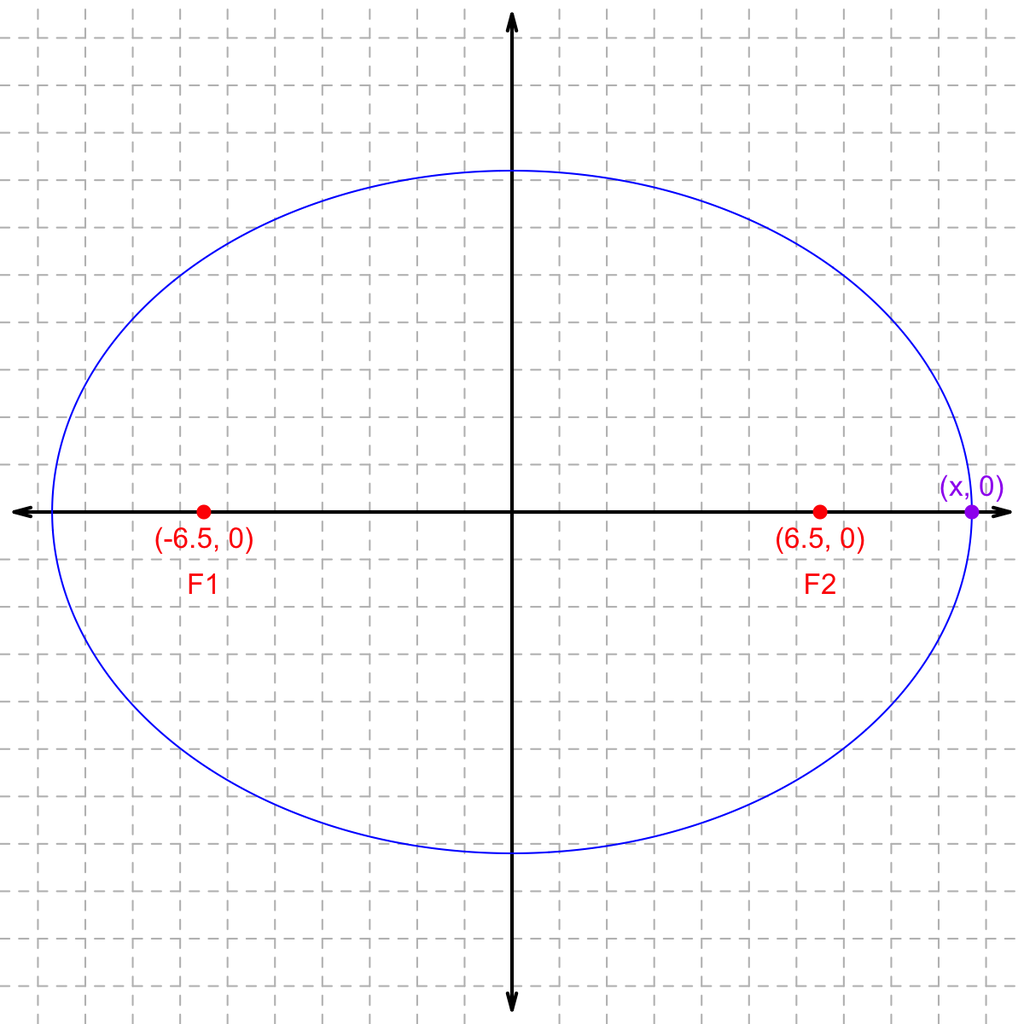

- $x=$

To find $a$, use the Pythagorean Theorem. The length $a$ is a hypotenuse of a right triangle with legs along the axes.

$$(6.5)^2 + (7.2)^2 =a^2$$

$$a ~=~ \sqrt{6.5^2+7.2^2} ~=~
9.7$$
Use multiplication by 2 to find the total distance from $F_1$ to (0,7.2) to $F_2$
$$2a =
19.4$$

It is easy to find $c$ from the graph. It is the distance from the center to either focus. In this graph, the center and the focus are on the same horizontal axis, so distance is just a difference, and the subtrahend is 0.

$$c=6.5$$
$$2c = 13$$

Use pythagorean theorem to find $s$.

$$s =
\sqrt{(5.22-(-6.5))^2+6.07^2}$$

$$s=13.1986098$$
$$s\approx13.2$$

Use pythagorean theorem to find $w$.

$$w =
\sqrt{(5.22-(6.5))^2+6.07^2}$$

$$w=6.203491$$
$$w\approx6.2$$

Add $s$ and $w$ to get the total distance.

$$s+w=19.4$$

Notice that $s+w=2a$, because the total distance is always $2a$ for any point on the edge.

To find $x$, use the fact that the total distance is $2a$.

$$(x-(-6.5))+(x-6.5)=19.4$$
$$x+6.5+x-6.5=19.4$$
$$2x=19.4$$
$$x=9.7$$

An [ellipse](https://en.wikipedia.org/wiki/Ellipse) is a set of points such that the total distance from (1) one focus to (2) the edge to (3) the other focus is constant for any point on the edge. The two foci ($F_1$ and $F_2$) are a distance $2c$ apart, and the total distance from $F_1$ to the edge to $F_2$ is a distance $2a$.

Let's consider the example below with foci at $(-7.7,0)$ and $(7.7,0)$ and a covertex at $(0, 3.6)$:

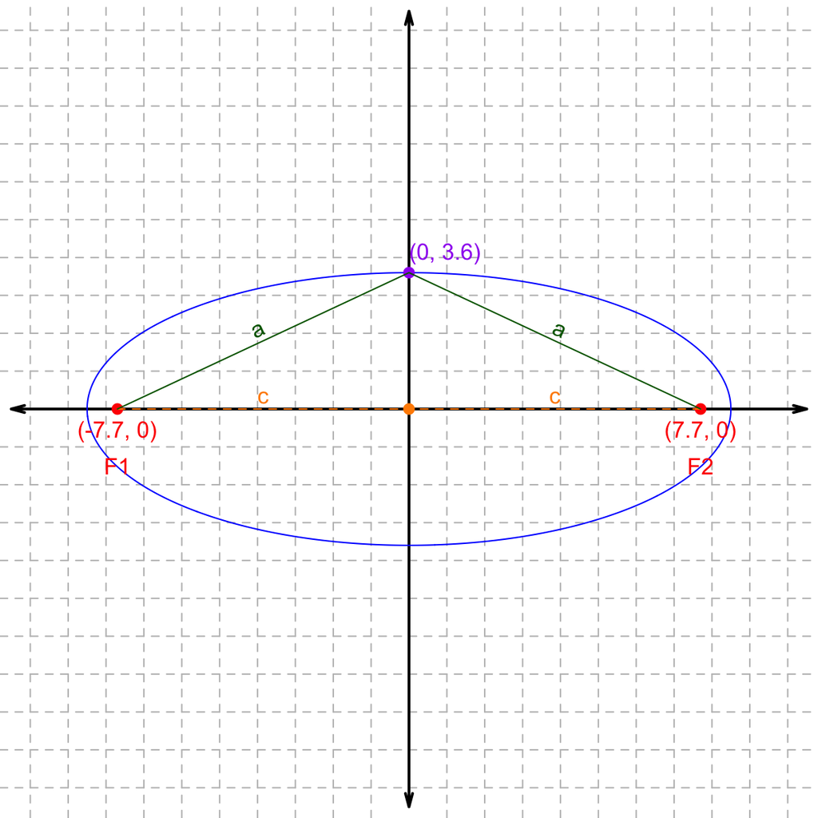

Evaluate $2a$ and $2c$.

- $a=$
- $2a=$
- $c=$
- $2c=$

Now, let's pick another point on the ellipse, with (approximate) coordinates (4.97, 2.92):

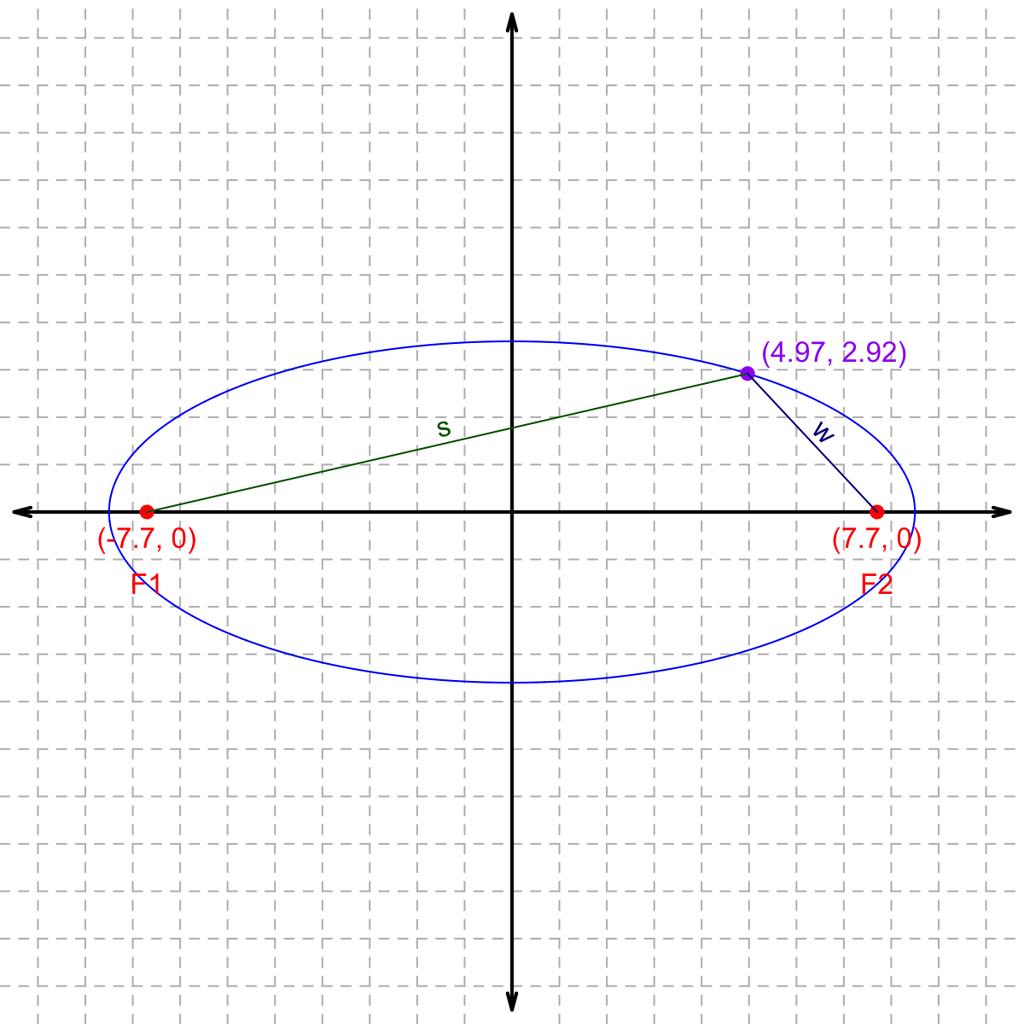

The distance $s$ is from $F_1$ to the point on the edge. The distance $w$ is from $F_2$ to the point on the edge. Evaluate $s$, $w$, and the total distance ($s+w$).

- $s=$
- $w=$
- $s+w=$

Remember, the total distance when connecting

1. The first focus $F_1$
2. Any point on the edge
3. The second focus $F_2$

equals $2a$. Based on this information, find the location of the right vertex at ($x$, 0) in the diagram below.

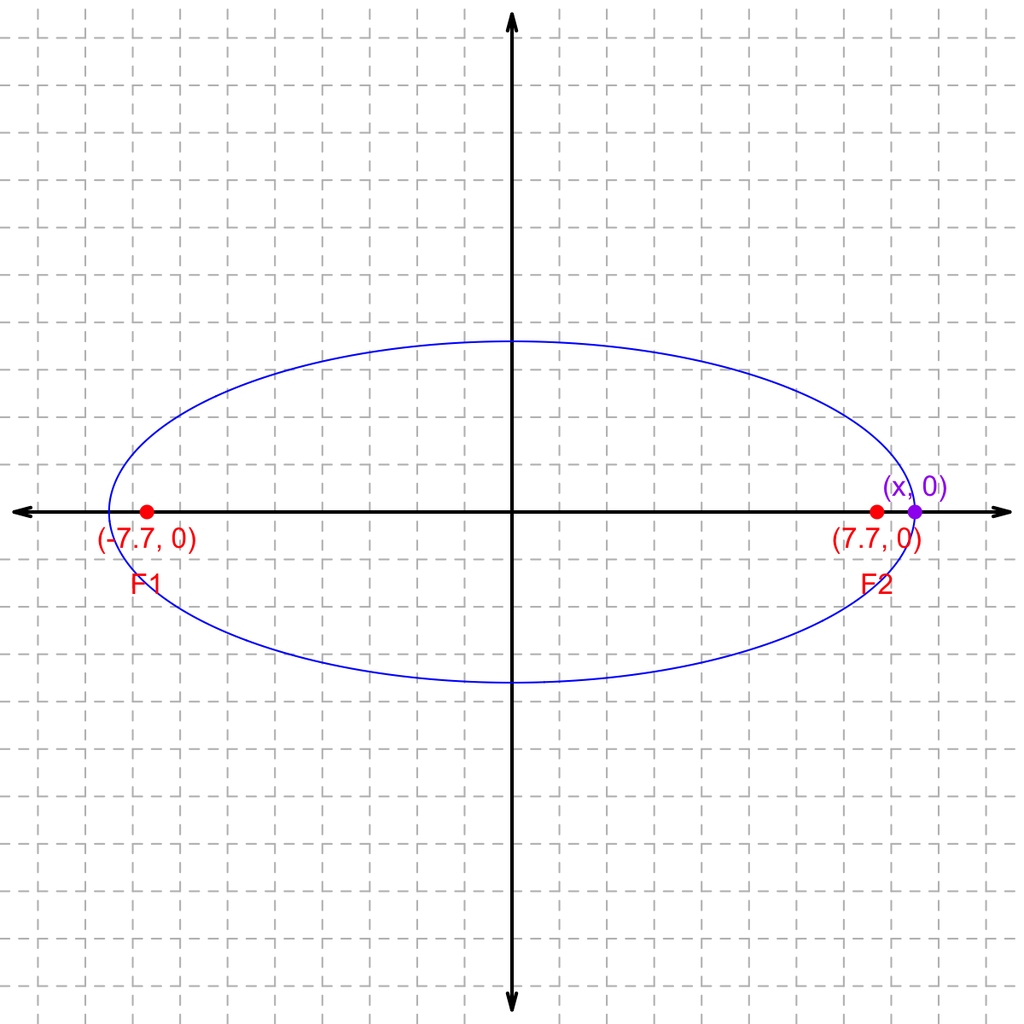

- $x=$

To find $a$, use the Pythagorean Theorem. The length $a$ is a hypotenuse of a right triangle with legs along the axes.

$$(7.7)^2 + (3.6)^2 =a^2$$

$$a ~=~ \sqrt{7.7^2+3.6^2} ~=~
8.5$$
Use multiplication by 2 to find the total distance from $F_1$ to (0,3.6) to $F_2$
$$2a =
17$$

It is easy to find $c$ from the graph. It is the distance from the center to either focus. In this graph, the center and the focus are on the same horizontal axis, so distance is just a difference, and the subtrahend is 0.

$$c=7.7$$
$$2c = 15.4$$

Use pythagorean theorem to find $s$.

$$s =
\sqrt{(4.97-(-7.7))^2+2.92^2}$$

$$s=13.0021267$$
$$s\approx13$$

Use pythagorean theorem to find $w$.

$$w =
\sqrt{(4.97-(7.7))^2+2.92^2}$$

$$w=3.9974117$$
$$w\approx4$$

Add $s$ and $w$ to get the total distance.

$$s+w=17$$

Notice that $s+w=2a$, because the total distance is always $2a$ for any point on the edge.

To find $x$, use the fact that the total distance is $2a$.

$$(x-(-7.7))+(x-7.7)=17$$
$$x+7.7+x-7.7=17$$
$$2x=17$$
$$x=8.5$$

An [ellipse](https://en.wikipedia.org/wiki/Ellipse) is the set of ($x$, $y$) points that satisfy the equation below.

$$\frac{(x-h)^2}{(r_1)^2}+\frac{(y-k)^2}{(r_2)^2}=1$$

where the center is $(h,k)$, the horizontal radius is $r_1$, and the vertical radius is $r_2$.

Determine the parameters of the ellipse in the graph below. You can assume all parameters are integers.

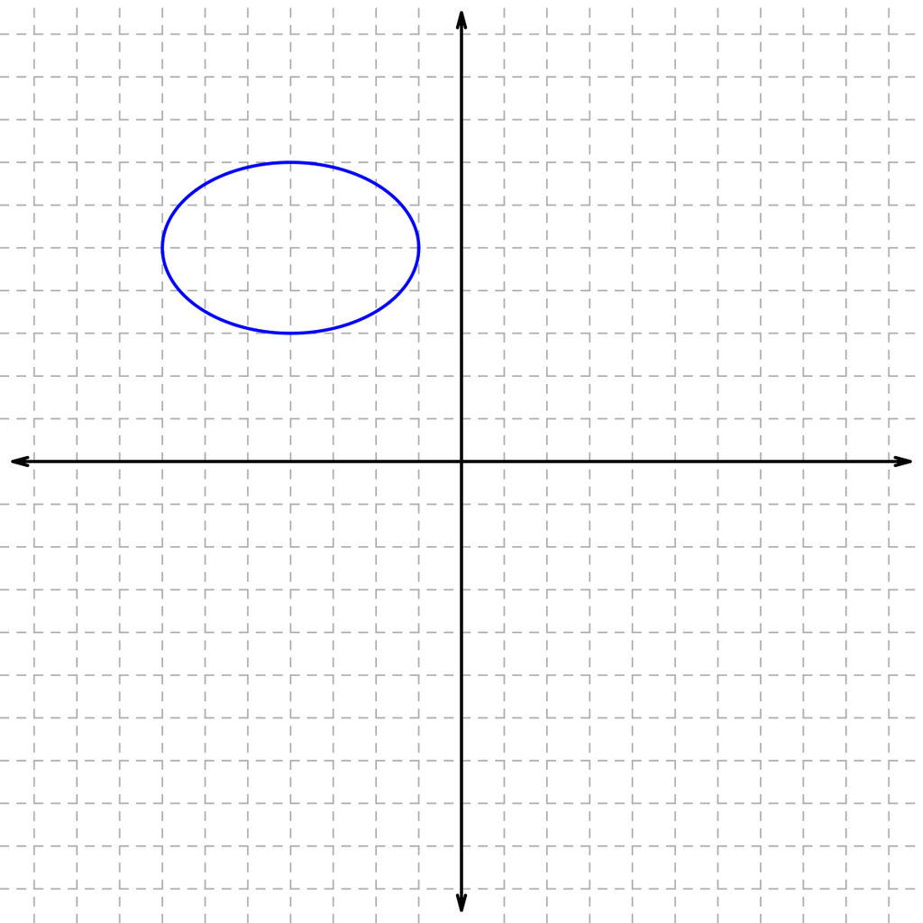

- $h=$
- $k=$
- $r_1=$
- $r_2=$

Which of the following equations would give the graph above?

$$\begin{align}
A&:~~\frac{(x+4)^2}{4}+\frac{(y+5)^2}{9}=1 &
B&:~~\frac{(x+4)^2}{4}+\frac{(y-5)^2}{9}=1 &
C&:~~\frac{(x-4)^2}{4}+\frac{(y+5)^2}{9}=1 &
D&:~~\frac{(x-4)^2}{4}+\frac{(y-5)^2}{9}=1 \\
E&:~~\frac{(x+5)^2}{4}+\frac{(y+4)^2}{9}=1 &
F&:~~\frac{(x+5)^2}{4}+\frac{(y-4)^2}{9}=1 &
G&:~~\frac{(x-5)^2}{4}+\frac{(y+4)^2}{9}=1 &
H&:~~\frac{(x-5)^2}{4}+\frac{(y-4)^2}{9}=1 \\
I&:~~\frac{(x+4)^2}{9}+\frac{(y+5)^2}{4}=1 &
J&:~~\frac{(x+4)^2}{9}+\frac{(y-5)^2}{4}=1 &
K&:~~\frac{(x-4)^2}{9}+\frac{(y+5)^2}{4}=1 &
L&:~~\frac{(x-4)^2}{9}+\frac{(y-5)^2}{4}=1 \\
M&:~~\frac{(x+5)^2}{9}+\frac{(y+4)^2}{4}=1 &
N&:~~\frac{(x+5)^2}{9}+\frac{(y-4)^2}{4}=1 &
O&:~~\frac{(x-5)^2}{9}+\frac{(y+4)^2}{4}=1 &
P&:~~\frac{(x-5)^2}{9}+\frac{(y-4)^2}{4}=1 \\
\end{align}$$

Equation

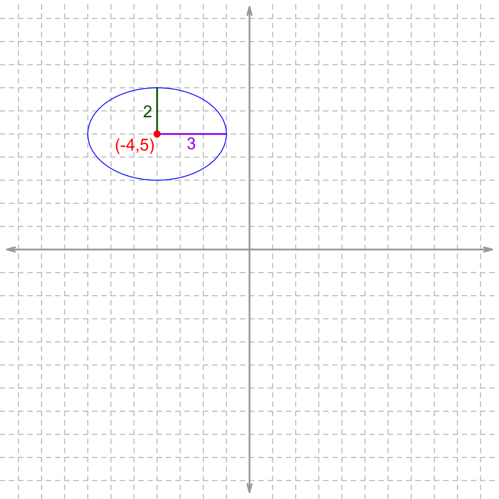

So:
$$\begin{align}
h &= -4\\\\
k &= 5\\\\
r_1 &= 3\\\\
r_2 &= 2
\end{align}$$

Substitute those numbers into the equation:

$$\frac{(x+4)^2}{9}+\frac{(y-5)^2}{4}=1$$

An [ellipse](https://en.wikipedia.org/wiki/Ellipse) is the set of ($x$, $y$) points that satisfy the equation below.

$$\frac{(x-h)^2}{(r_1)^2}+\frac{(y-k)^2}{(r_2)^2}=1$$

where the center is $(h,k)$, the horizontal radius is $r_1$, and the vertical radius is $r_2$.

Determine the parameters of the ellipse in the graph below. You can assume all parameters are integers.

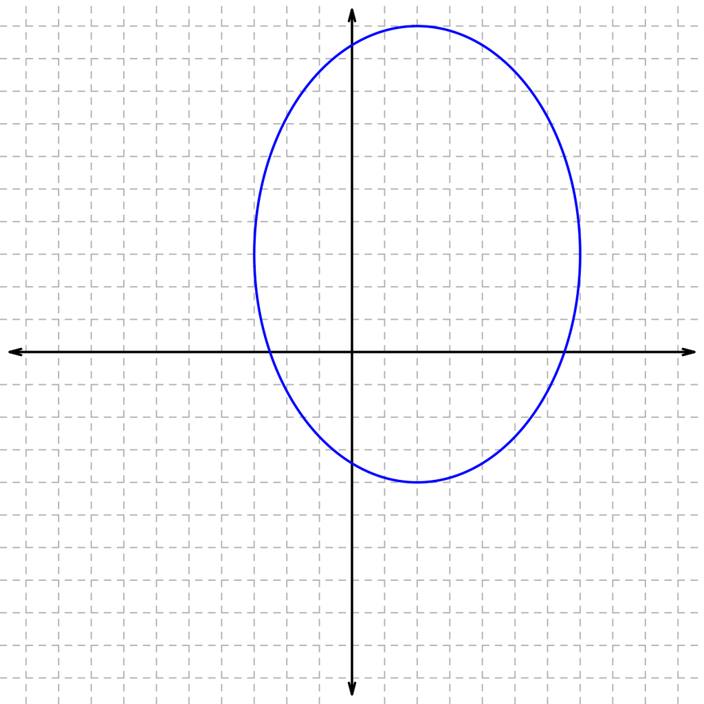

- $h=$
- $k=$
- $r_1=$
- $r_2=$

Which of the following equations would give the graph above?

$$\begin{align}
A&:~~\frac{(x+2)^2}{25}+\frac{(y+3)^2}{49}=1 &
B&:~~\frac{(x+2)^2}{25}+\frac{(y-3)^2}{49}=1 &
C&:~~\frac{(x-2)^2}{25}+\frac{(y+3)^2}{49}=1 &
D&:~~\frac{(x-2)^2}{25}+\frac{(y-3)^2}{49}=1 \\
E&:~~\frac{(x+3)^2}{25}+\frac{(y+2)^2}{49}=1 &
F&:~~\frac{(x+3)^2}{25}+\frac{(y-2)^2}{49}=1 &
G&:~~\frac{(x-3)^2}{25}+\frac{(y+2)^2}{49}=1 &
H&:~~\frac{(x-3)^2}{25}+\frac{(y-2)^2}{49}=1 \\
I&:~~\frac{(x+2)^2}{49}+\frac{(y+3)^2}{25}=1 &
J&:~~\frac{(x+2)^2}{49}+\frac{(y-3)^2}{25}=1 &
K&:~~\frac{(x-2)^2}{49}+\frac{(y+3)^2}{25}=1 &
L&:~~\frac{(x-2)^2}{49}+\frac{(y-3)^2}{25}=1 \\
M&:~~\frac{(x+3)^2}{49}+\frac{(y+2)^2}{25}=1 &
N&:~~\frac{(x+3)^2}{49}+\frac{(y-2)^2}{25}=1 &
O&:~~\frac{(x-3)^2}{49}+\frac{(y+2)^2}{25}=1 &
P&:~~\frac{(x-3)^2}{49}+\frac{(y-2)^2}{25}=1 \\
\end{align}$$

Equation

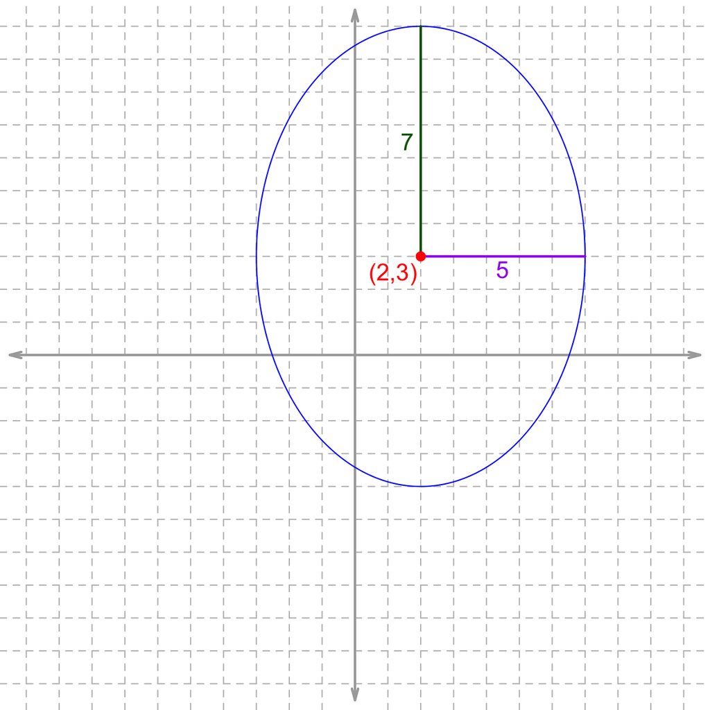

So:
$$\begin{align}
h &= 2\\\\
k &= 3\\\\
r_1 &= 5\\\\
r_2 &= 7
\end{align}$$

Substitute those numbers into the equation:

$$\frac{(x-2)^2}{25}+\frac{(y-3)^2}{49}=1$$

An [ellipse](https://en.wikipedia.org/wiki/Ellipse) is the set of ($x$, $y$) points that satisfy the equation below.

$$\frac{(x-h)^2}{(r_1)^2}+\frac{(y-k)^2}{(r_2)^2}=1$$

where the center is $(h,k)$, the horizontal radius is $r_1$, and the vertical radius is $r_2$.

Determine the parameters of the ellipse in the graph below. You can assume all parameters are integers.

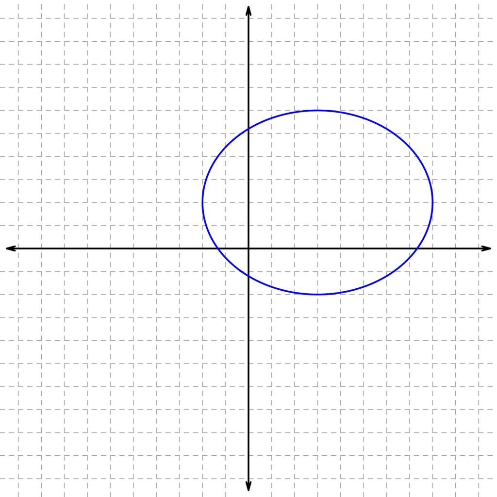

- $h=$
- $k=$
- $r_1=$
- $r_2=$

Which of the following equations would give the graph above?

$$\begin{align}
A&:~~\frac{(x+2)^2}{16}+\frac{(y+3)^2}{25}=1 &
B&:~~\frac{(x+2)^2}{16}+\frac{(y-3)^2}{25}=1 &
C&:~~\frac{(x-2)^2}{16}+\frac{(y+3)^2}{25}=1 &
D&:~~\frac{(x-2)^2}{16}+\frac{(y-3)^2}{25}=1 \\
E&:~~\frac{(x+3)^2}{16}+\frac{(y+2)^2}{25}=1 &
F&:~~\frac{(x+3)^2}{16}+\frac{(y-2)^2}{25}=1 &
G&:~~\frac{(x-3)^2}{16}+\frac{(y+2)^2}{25}=1 &
H&:~~\frac{(x-3)^2}{16}+\frac{(y-2)^2}{25}=1 \\
I&:~~\frac{(x+2)^2}{25}+\frac{(y+3)^2}{16}=1 &
J&:~~\frac{(x+2)^2}{25}+\frac{(y-3)^2}{16}=1 &
K&:~~\frac{(x-2)^2}{25}+\frac{(y+3)^2}{16}=1 &
L&:~~\frac{(x-2)^2}{25}+\frac{(y-3)^2}{16}=1 \\
M&:~~\frac{(x+3)^2}{25}+\frac{(y+2)^2}{16}=1 &
N&:~~\frac{(x+3)^2}{25}+\frac{(y-2)^2}{16}=1 &
O&:~~\frac{(x-3)^2}{25}+\frac{(y+2)^2}{16}=1 &
P&:~~\frac{(x-3)^2}{25}+\frac{(y-2)^2}{16}=1 \\
\end{align}$$

Equation

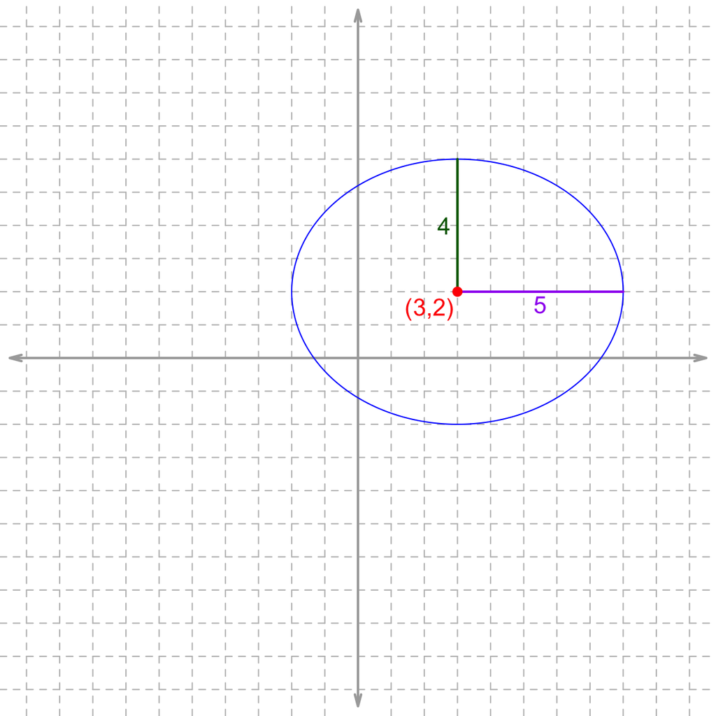

So:
$$\begin{align}
h &= 3\\\\
k &= 2\\\\
r_1 &= 5\\\\
r_2 &= 4
\end{align}$$

Substitute those numbers into the equation:

$$\frac{(x-3)^2}{25}+\frac{(y-2)^2}{16}=1$$

An [ellipse](https://en.wikipedia.org/wiki/Ellipse) is the set of ($x$, $y$) points that satisfy the equation below.

$$\frac{(x-h)^2}{(r_1)^2}+\frac{(y-k)^2}{(r_2)^2}=1$$

where the center is $(h,k)$, the horizontal radius is $r_1$, and the vertical radius is $r_2$.

Determine the parameters of the ellipse in the graph below. You can assume all parameters are integers.

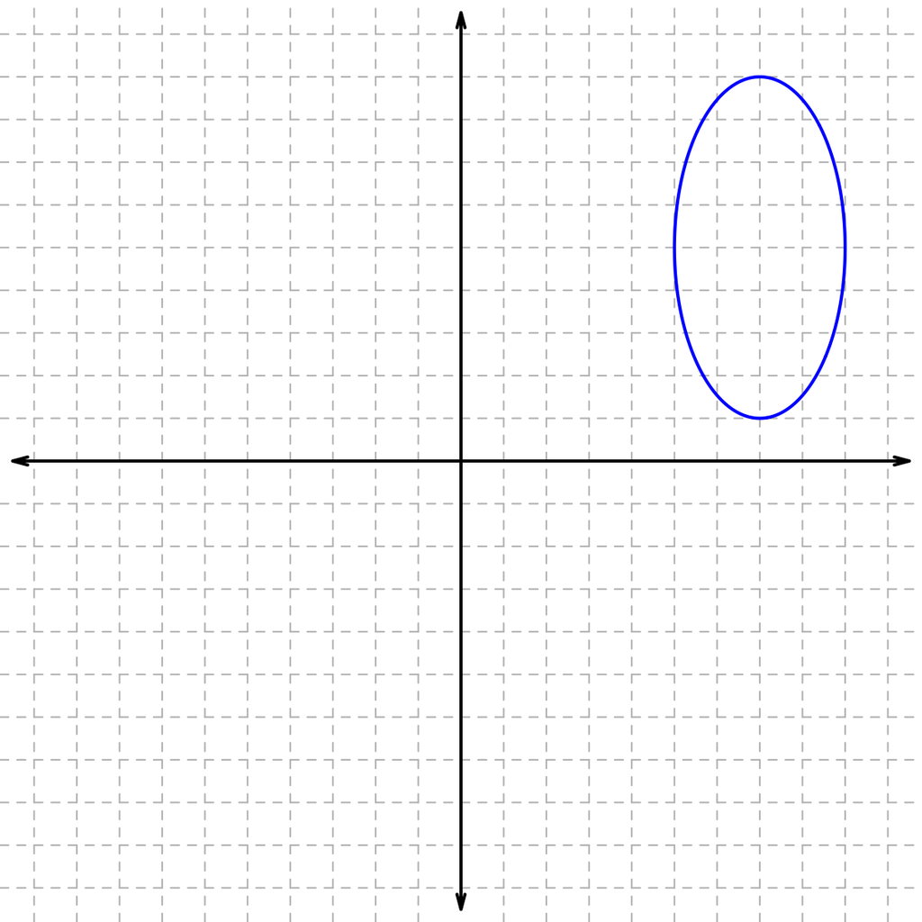

- $h=$
- $k=$
- $r_1=$
- $r_2=$

Which of the following equations would give the graph above?

$$\begin{align}
A&:~~\frac{(x+5)^2}{4}+\frac{(y+7)^2}{16}=1 &
B&:~~\frac{(x+5)^2}{4}+\frac{(y-7)^2}{16}=1 &
C&:~~\frac{(x-5)^2}{4}+\frac{(y+7)^2}{16}=1 &
D&:~~\frac{(x-5)^2}{4}+\frac{(y-7)^2}{16}=1 \\
E&:~~\frac{(x+7)^2}{4}+\frac{(y+5)^2}{16}=1 &
F&:~~\frac{(x+7)^2}{4}+\frac{(y-5)^2}{16}=1 &
G&:~~\frac{(x-7)^2}{4}+\frac{(y+5)^2}{16}=1 &
H&:~~\frac{(x-7)^2}{4}+\frac{(y-5)^2}{16}=1 \\
I&:~~\frac{(x+5)^2}{16}+\frac{(y+7)^2}{4}=1 &
J&:~~\frac{(x+5)^2}{16}+\frac{(y-7)^2}{4}=1 &
K&:~~\frac{(x-5)^2}{16}+\frac{(y+7)^2}{4}=1 &
L&:~~\frac{(x-5)^2}{16}+\frac{(y-7)^2}{4}=1 \\
M&:~~\frac{(x+7)^2}{16}+\frac{(y+5)^2}{4}=1 &
N&:~~\frac{(x+7)^2}{16}+\frac{(y-5)^2}{4}=1 &
O&:~~\frac{(x-7)^2}{16}+\frac{(y+5)^2}{4}=1 &
P&:~~\frac{(x-7)^2}{16}+\frac{(y-5)^2}{4}=1 \\
\end{align}$$

Equation

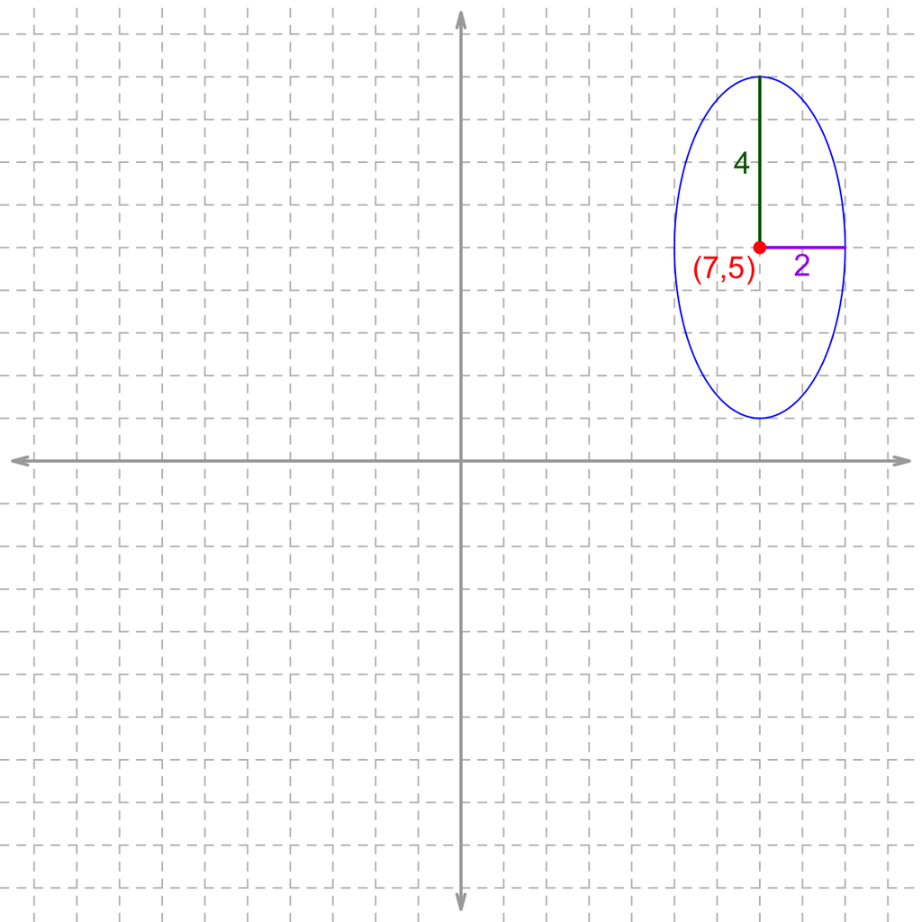

So:
$$\begin{align}
h &= 7\\\\
k &= 5\\\\
r_1 &= 2\\\\
r_2 &= 4
\end{align}$$

Substitute those numbers into the equation:

$$\frac{(x-7)^2}{4}+\frac{(y-5)^2}{16}=1$$

The following equation (in polynomial form) represents an ellipse.

$$81x^2+324x+49y^2-98y-3596=0$$

With some algebra ([completing the square](https://en.wikipedia.org/wiki/Completing_the_square)), you can convert the equation into standard form:

$$\frac{(x-h)^2}{(r_1)^2}+\frac{(y-k)^2}{(r_2)^2}=1$$

From the given polynomial form, determine the 4 parameters.

- $h=$
- $k=$
- $r_1=$
- $r_2=$

$$81x^2+324x+49y^2-98y-3596=0$$
Factor out the quadratic coefficients from each variable's polynomial. Also move the constant term to the right with addition/subtration.

$$81(x^2+4x)+49(y^2-2y)=3596$$

Complete the square for the $x$ quadratic. If $x^2+bx+c$ is a perfect square, then $c=\left(\frac{b}{2}\right)^2$. In this case, the linear coefficient is $4$. If you divide it by 2 and square the result, you get the necessary constant to complete the square (4). Notice $(x+2)^2\equiv x^2+4x+4$. Lastly, since we are adding 4 inside parentheses with a multiplier of 81, we are technically adding 324 to both sides to make an equivalent equation.

$$81(x^2+4x+4)+49(y^2-2y)=3596+324$$

Complete the square for the $y$ quadratic. If $y^2+by+c$ is a perfect square, then $c=\left(\frac{b}{2}\right)^2$. In this case, the linear coefficient is $-2$. If you divide it by 2 and square the result, you get the necessary constant to complete the square (1). Notice $(y-1)^2\equiv y^2-2x+1$. Lastly, since we are adding 1 inside parentheses with a multiplier of 49, we are technically adding 49 to both sides to make an equivalent equation.

$$81(x^2+4x+4)+49(y^2-2y+1)=3596+324+49$$

Combine the constants.

$$81(x^2+4x+4)+49(y^2-2y+1)=3969$$

O yeah, remember how you completed the square? Twice? Let's rewrite those quadratic expressions in factored form. (This could have been done earlier.)

$$81(x+2)^2+49(y-1)^2=3969$$

Divide both sides by $3969$.

$$\frac{81(x+2)^2}{3969}+\frac{49(y-1)^2}{3969}=1$$

Simplify the fractions. Notice that $\frac{81}{3969}= \frac{1}{49}$ and $\frac{49}{3969}= \frac{1}{81}$.

$$\frac{(x+2)^2}{49}+\frac{(y-1)^2}{81}=1$$

If you find the square roots of both denominators, you will have the standard form of an ellipse. Notice $\sqrt{49}=7$ and $\sqrt{81}=9$.

$$\frac{(x+2)^2}{7^2}+\frac{(y-1)^2}{9^2}=1$$

Thus,

$$\begin{align}
h &= -2 \\
k &= 1 \\
r_1 &= 7 \\
r_2 &= 9
\end{align}$$

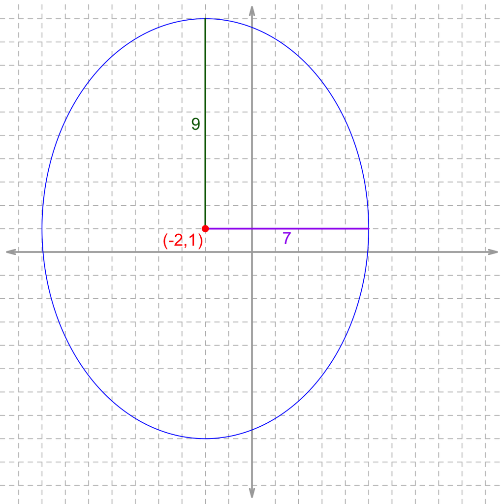

The following equation (in polynomial form) represents an ellipse.

$$9x^2-18x+4y^2+56y+169=0$$

With some algebra ([completing the square](https://en.wikipedia.org/wiki/Completing_the_square)), you can convert the equation into standard form:

$$\frac{(x-h)^2}{(r_1)^2}+\frac{(y-k)^2}{(r_2)^2}=1$$

From the given polynomial form, determine the 4 parameters.

- $h=$
- $k=$
- $r_1=$
- $r_2=$

$$9x^2-18x+4y^2+56y+169=0$$
Factor out the quadratic coefficients from each variable's polynomial. Also move the constant term to the right with addition/subtration.

$$9(x^2-2x)+4(y^2+14y)=-169$$

Complete the square for the $x$ quadratic. If $x^2+bx+c$ is a perfect square, then $c=\left(\frac{b}{2}\right)^2$. In this case, the linear coefficient is $-2$. If you divide it by 2 and square the result, you get the necessary constant to complete the square (1). Notice $(x-1)^2\equiv x^2-2x+1$. Lastly, since we are adding 1 inside parentheses with a multiplier of 9, we are technically adding 9 to both sides to make an equivalent equation.

$$9(x^2-2x+1)+4(y^2+14y)=-169+9$$

Complete the square for the $y$ quadratic. If $y^2+by+c$ is a perfect square, then $c=\left(\frac{b}{2}\right)^2$. In this case, the linear coefficient is $14$. If you divide it by 2 and square the result, you get the necessary constant to complete the square (49). Notice $(y+7)^2\equiv y^2+14x+49$. Lastly, since we are adding 49 inside parentheses with a multiplier of 4, we are technically adding 196 to both sides to make an equivalent equation.

$$9(x^2-2x+1)+4(y^2+14y+49)=-169+9+196$$

Combine the constants.

$$9(x^2-2x+1)+4(y^2+14y+49)=36$$

O yeah, remember how you completed the square? Twice? Let's rewrite those quadratic expressions in factored form. (This could have been done earlier.)

$$9(x-1)^2+4(y+7)^2=36$$

Divide both sides by $36$.

$$\frac{9(x-1)^2}{36}+\frac{4(y+7)^2}{36}=1$$

Simplify the fractions. Notice that $\frac{9}{36}= \frac{1}{4}$ and $\frac{4}{36}= \frac{1}{9}$.

$$\frac{(x-1)^2}{4}+\frac{(y+7)^2}{9}=1$$

If you find the square roots of both denominators, you will have the standard form of an ellipse. Notice $\sqrt{4}=2$ and $\sqrt{9}=3$.

$$\frac{(x-1)^2}{2^2}+\frac{(y+7)^2}{3^2}=1$$

Thus,

$$\begin{align}
h &= 1 \\
k &= -7 \\
r_1 &= 2 \\
r_2 &= 3
\end{align}$$

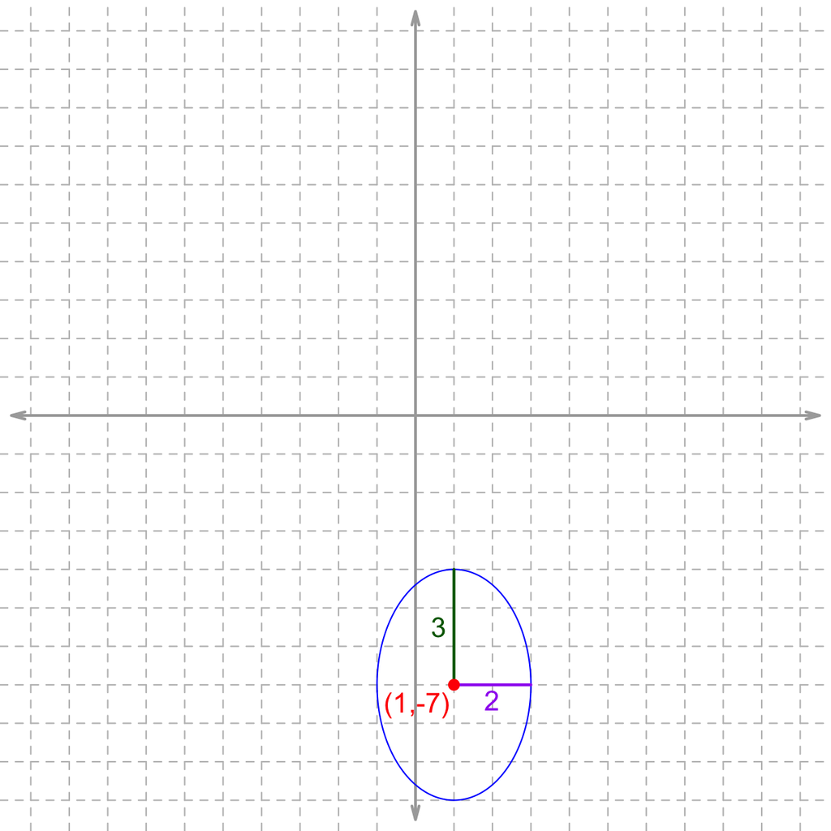

The following equation (in polynomial form) represents an ellipse.

$$36x^2+144x+9y^2+72y-36=0$$

With some algebra ([completing the square](https://en.wikipedia.org/wiki/Completing_the_square)), you can convert the equation into standard form:

$$\frac{(x-h)^2}{(r_1)^2}+\frac{(y-k)^2}{(r_2)^2}=1$$

From the given polynomial form, determine the 4 parameters.

- $h=$
- $k=$
- $r_1=$
- $r_2=$

$$36x^2+144x+9y^2+72y-36=0$$
Factor out the quadratic coefficients from each variable's polynomial. Also move the constant term to the right with addition/subtration.

$$36(x^2+4x)+9(y^2+8y)=36$$

Complete the square for the $x$ quadratic. If $x^2+bx+c$ is a perfect square, then $c=\left(\frac{b}{2}\right)^2$. In this case, the linear coefficient is $4$. If you divide it by 2 and square the result, you get the necessary constant to complete the square (4). Notice $(x+2)^2\equiv x^2+4x+4$. Lastly, since we are adding 4 inside parentheses with a multiplier of 36, we are technically adding 144 to both sides to make an equivalent equation.

$$36(x^2+4x+4)+9(y^2+8y)=36+144$$

Complete the square for the $y$ quadratic. If $y^2+by+c$ is a perfect square, then $c=\left(\frac{b}{2}\right)^2$. In this case, the linear coefficient is $8$. If you divide it by 2 and square the result, you get the necessary constant to complete the square (16). Notice $(y+4)^2\equiv y^2+8x+16$. Lastly, since we are adding 16 inside parentheses with a multiplier of 9, we are technically adding 144 to both sides to make an equivalent equation.

$$36(x^2+4x+4)+9(y^2+8y+16)=36+144+144$$

Combine the constants.

$$36(x^2+4x+4)+9(y^2+8y+16)=324$$

O yeah, remember how you completed the square? Twice? Let's rewrite those quadratic expressions in factored form. (This could have been done earlier.)

$$36(x+2)^2+9(y+4)^2=324$$

Divide both sides by $324$.

$$\frac{36(x+2)^2}{324}+\frac{9(y+4)^2}{324}=1$$

Simplify the fractions. Notice that $\frac{36}{324}= \frac{1}{9}$ and $\frac{9}{324}= \frac{1}{36}$.

$$\frac{(x+2)^2}{9}+\frac{(y+4)^2}{36}=1$$

If you find the square roots of both denominators, you will have the standard form of an ellipse. Notice $\sqrt{9}=3$ and $\sqrt{36}=6$.

$$\frac{(x+2)^2}{3^2}+\frac{(y+4)^2}{6^2}=1$$

Thus,

$$\begin{align}
h &= -2 \\
k &= -4 \\
r_1 &= 3 \\
r_2 &= 6
\end{align}$$

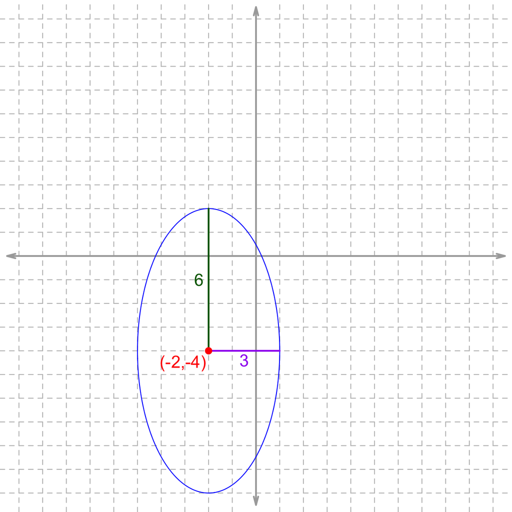

The following equation (in polynomial form) represents an ellipse.

$$81x^2-972x+16y^2+32y+1636=0$$

With some algebra ([completing the square](https://en.wikipedia.org/wiki/Completing_the_square)), you can convert the equation into standard form:

$$\frac{(x-h)^2}{(r_1)^2}+\frac{(y-k)^2}{(r_2)^2}=1$$

From the given polynomial form, determine the 4 parameters.

- $h=$
- $k=$
- $r_1=$
- $r_2=$

$$81x^2-972x+16y^2+32y+1636=0$$
Factor out the quadratic coefficients from each variable's polynomial. Also move the constant term to the right with addition/subtration.

$$81(x^2-12x)+16(y^2+2y)=-1636$$

Complete the square for the $x$ quadratic. If $x^2+bx+c$ is a perfect square, then $c=\left(\frac{b}{2}\right)^2$. In this case, the linear coefficient is $-12$. If you divide it by 2 and square the result, you get the necessary constant to complete the square (36). Notice $(x-6)^2\equiv x^2-12x+36$. Lastly, since we are adding 36 inside parentheses with a multiplier of 81, we are technically adding 2916 to both sides to make an equivalent equation.

$$81(x^2-12x+36)+16(y^2+2y)=-1636+2916$$

Complete the square for the $y$ quadratic. If $y^2+by+c$ is a perfect square, then $c=\left(\frac{b}{2}\right)^2$. In this case, the linear coefficient is $2$. If you divide it by 2 and square the result, you get the necessary constant to complete the square (1). Notice $(y+1)^2\equiv y^2+2x+1$. Lastly, since we are adding 1 inside parentheses with a multiplier of 16, we are technically adding 16 to both sides to make an equivalent equation.

$$81(x^2-12x+36)+16(y^2+2y+1)=-1636+2916+16$$

Combine the constants.

$$81(x^2-12x+36)+16(y^2+2y+1)=1296$$

O yeah, remember how you completed the square? Twice? Let's rewrite those quadratic expressions in factored form. (This could have been done earlier.)

$$81(x-6)^2+16(y+1)^2=1296$$

Divide both sides by $1296$.

$$\frac{81(x-6)^2}{1296}+\frac{16(y+1)^2}{1296}=1$$

Simplify the fractions. Notice that $\frac{81}{1296}= \frac{1}{16}$ and $\frac{16}{1296}= \frac{1}{81}$.

$$\frac{(x-6)^2}{16}+\frac{(y+1)^2}{81}=1$$

If you find the square roots of both denominators, you will have the standard form of an ellipse. Notice $\sqrt{16}=4$ and $\sqrt{81}=9$.

$$\frac{(x-6)^2}{4^2}+\frac{(y+1)^2}{9^2}=1$$

Thus,

$$\begin{align}
h &= 6 \\
k &= -1 \\
r_1 &= 4 \\
r_2 &= 9
\end{align}$$

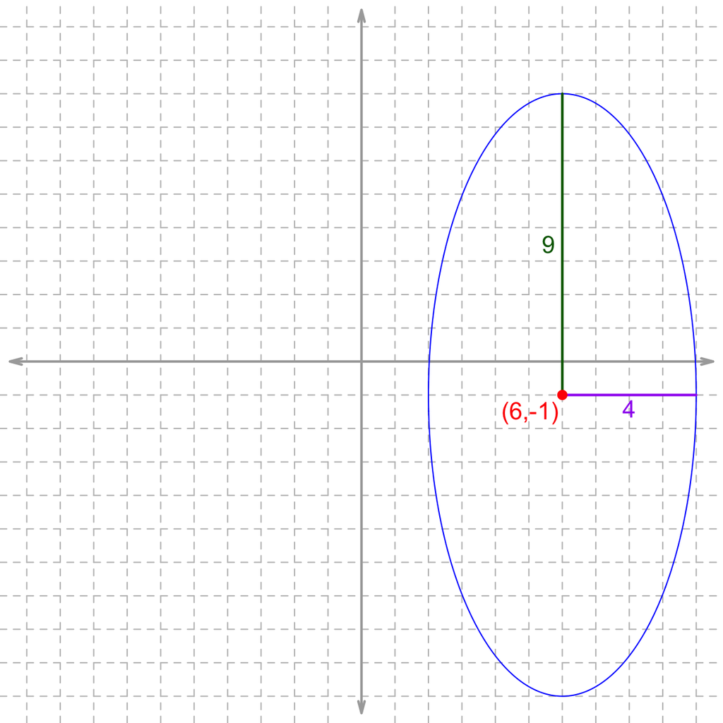

A circle with radius $r=9$ centimeters is cut into 5 congruent sectors. A length of red string is pulled around the circle, and the string is exactly long enough to span the arc of 3 adjacent sectors, as shown in the diagram below.

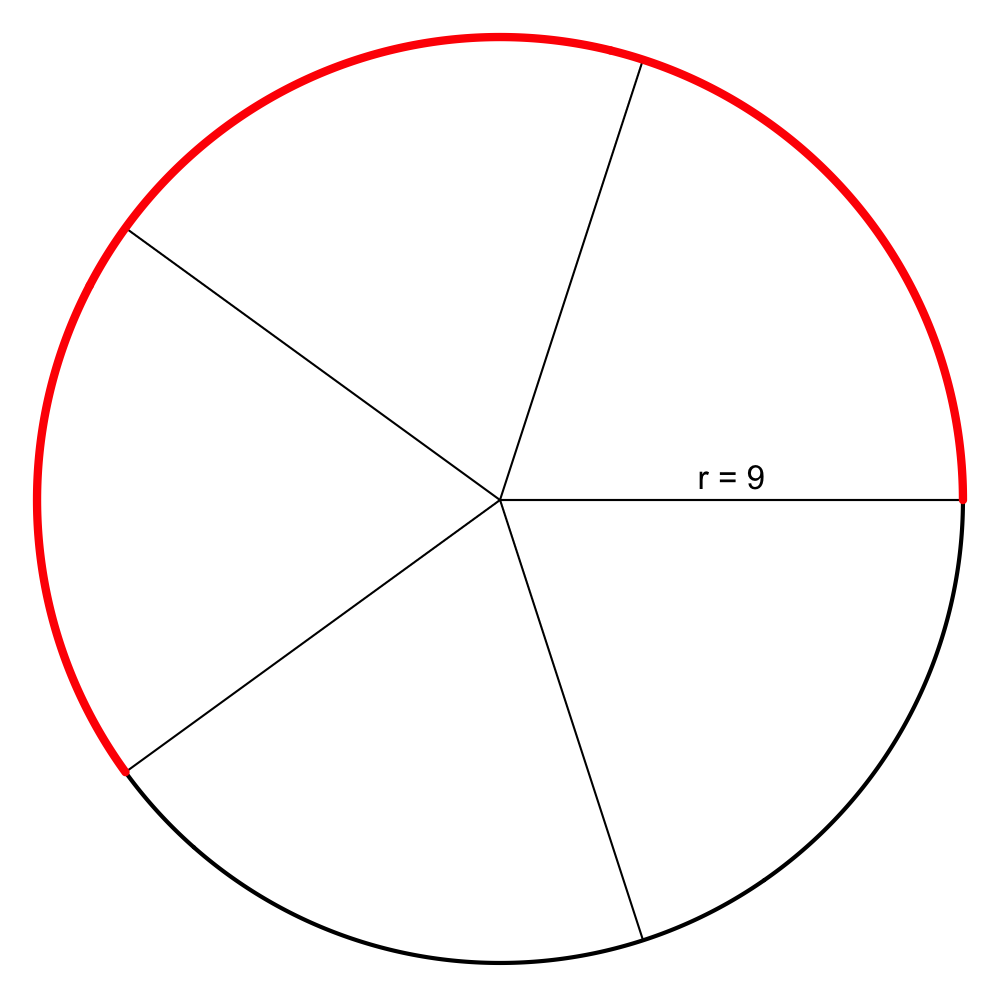

How long, in centimeters, is the red string? Please answer as a decimal approximation accurate within $\pm 0.01$ centimeters.

Find the [diameter](https://en.wikipedia.org/wiki/Diameter).

$$d=2r$$
$$d=2\cdot9$$
$$d=18$$

Find the [circumference](https://en.wikipedia.org/wiki/Circumference).

$$C = \pi d$$
$$C = \pi \cdot 18$$
$$C~\approx~56.5486678$$

The [string's length](https://en.wikipedia.org/wiki/Circular_arc) is $\frac{3}{5}$ of the circumference.

$$L~=~\frac{3}{5}C$$
$$L~=~\frac{3}{5}d\pi$$
$$L~=~\frac{3}{5}2\pi r$$
$$L~\approx~\frac{3}{5}(56.5486678)$$
$$L~\approx~33.9292007$$

A circle with radius $r=9$ centimeters is cut into 7 congruent sectors. A length of red string is pulled around the circle, and the string is exactly long enough to span the arc of 2 adjacent sectors, as shown in the diagram below.

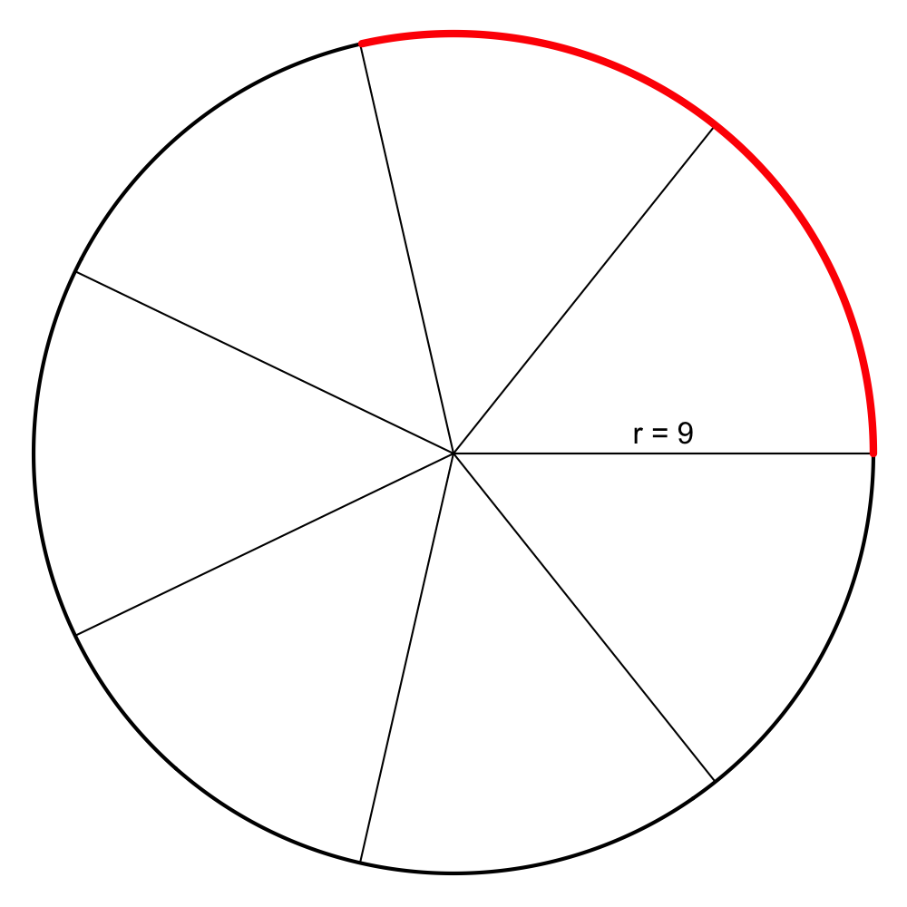

How long, in centimeters, is the red string? Please answer as a decimal approximation accurate within $\pm 0.01$ centimeters.

Find the [diameter](https://en.wikipedia.org/wiki/Diameter).

$$d=2r$$
$$d=2\cdot9$$
$$d=18$$

Find the [circumference](https://en.wikipedia.org/wiki/Circumference).

$$C = \pi d$$
$$C = \pi \cdot 18$$
$$C~\approx~56.5486678$$

The [string's length](https://en.wikipedia.org/wiki/Circular_arc) is $\frac{2}{7}$ of the circumference.

$$L~=~\frac{2}{7}C$$
$$L~=~\frac{2}{7}d\pi$$
$$L~=~\frac{2}{7}2\pi r$$
$$L~\approx~\frac{2}{7}(56.5486678)$$
$$L~\approx~16.1567622$$

A circle with radius $r=4$ centimeters is cut into 9 congruent sectors. A length of red string is pulled around the circle, and the string is exactly long enough to span the arc of 2 adjacent sectors, as shown in the diagram below.

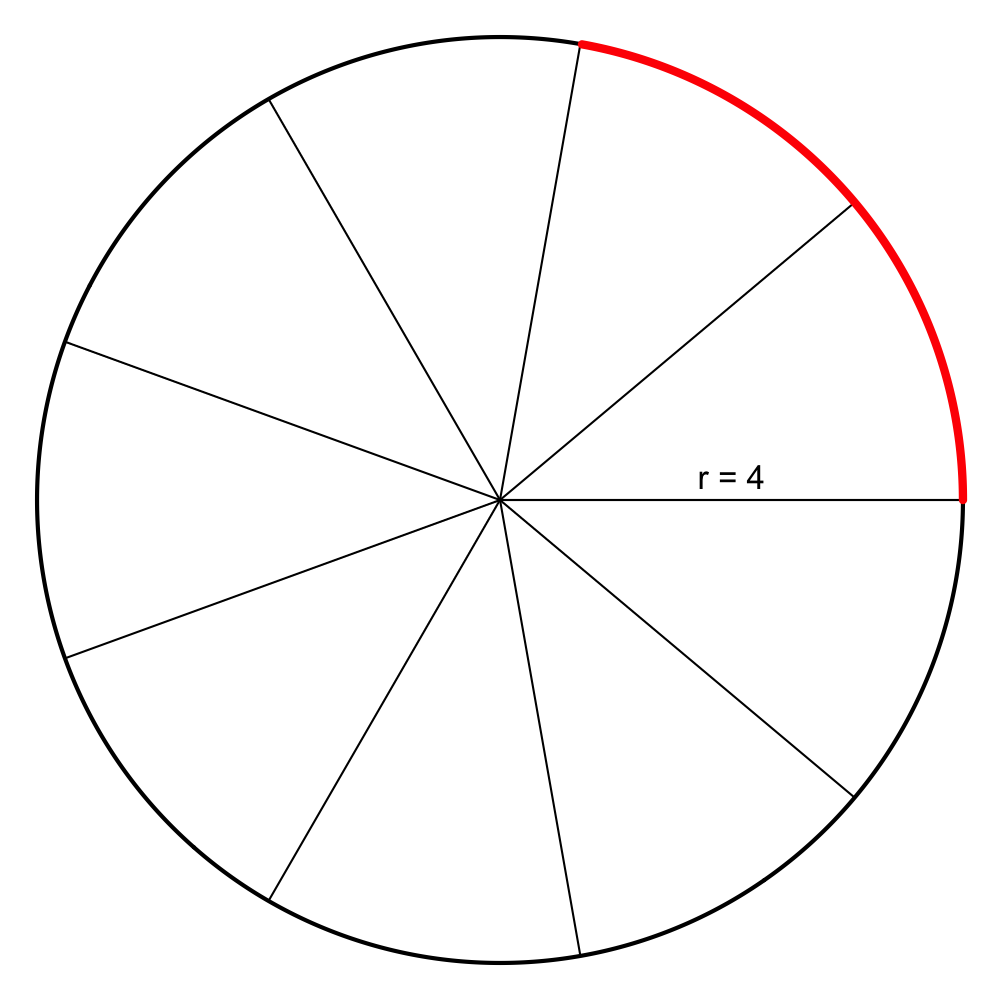

How long, in centimeters, is the red string? Please answer as a decimal approximation accurate within $\pm 0.01$ centimeters.

Find the [diameter](https://en.wikipedia.org/wiki/Diameter).

$$d=2r$$
$$d=2\cdot4$$
$$d=8$$

Find the [circumference](https://en.wikipedia.org/wiki/Circumference).

$$C = \pi d$$
$$C = \pi \cdot 8$$
$$C~\approx~25.1327412$$

The [string's length](https://en.wikipedia.org/wiki/Circular_arc) is $\frac{2}{9}$ of the circumference.